# JoeSchueder_Livesession4assignment

Joe Schueder

September 22, 2017

## Questions

### 1 FiveThirtyEight Data (30 points): Navigate on GitHub to https://github.com/rudeboybert/fivethirtyeight and read README.md. Seriously, it will include every command you need. Test out some commands on R.

#### a. Install the fivethirtyeight package.

#### b. In the listing of Data sets in package ‘fivethirtyeight,’ assign the eighteenth data set to an object ‘df.’

#### c. Use a more detailed list of the data sets to write out the URL in a comment to the related news story.

#### d. Using R command(s), give the dimensions and column names of this data frame.

```r
#install.packages("fivethirtyeight")
df <- fivethirtyeight::college_recent_grads
#vignette("fivethirtyeight", package = "fivethirtyeight")
#Number of rows and columns:
dim(df)
```

```
## [1] 173  21
```

```r
#column names:
colnames(df)
```

```
##  [1] "rank"                        "major_code"
##  [3] "major"                       "major_category"
##  [5] "total"                       "sample_size"
##  [7] "men"                         "women"
##  [9] "sharewomen"                  "employed"
## [11] "employed_fulltime"           "employed_parttime"
## [13] "employed_fulltime_yearround" "unemployed"
## [15] "unemployment_rate"           "p25th"
## [17] "median"                      "p75th"
## [19] "college_jobs"                "non_college_jobs"
## [21] "low_wage_jobs"
```

### 2. Data Summary (30 points): Use your newly assigned data frame for Question 2.

#### a. Write an R command that gives you the column names of the data frame. Right after that, write one that counts the number of columns but not rows. Hint: The number should match one of your numbers in Question 1d for dimensions.

#### b. Generate a count of each unique major_category in the data frame. I recommend using libraries to help. I have demonstrated one briefly in live-session. To be clear, this should look like a matrix or data frame containing the major_category and the frequency it occurs in the dataset. Assign it to major_count.

#### c. To make things easier to read, enter par(las=2) before your plot to make the text perpendicular to the axis. Make a barplot of major_count. Make sure to label the title with something informative (check the vignette if you need), label the x and y axis, and make it any color other than grey. Assign the major_category labels to their respective bar. Flip the barplot horizontally so that bars extend to the right, not upward. All of these options can be done in a single pass of barplot(). Note: It’s okay if it’s wider than the preview pane.

#### d. Write the fivethirtyeight data to a csv file. Make sure that it does not have row labels

```r
#column names:
colnames(df)
```

```
##  [1] "rank"                        "major_code"
##  [3] "major"                       "major_category"
##  [5] "total"                       "sample_size"
##  [7] "men"                         "women"
##  [9] "sharewomen"                  "employed"
## [11] "employed_fulltime"           "employed_parttime"
## [13] "employed_fulltime_yearround" "unemployed"
## [15] "unemployment_rate"           "p25th"
## [17] "median"                      "p75th"
## [19] "college_jobs"                "non_college_jobs"
## [21] "low_wage_jobs"
```

```r
#Column count
ncol(df)
```

```
## [1] 21
```

```r
#count of unique categories and assign to major count
major_count <- lapply(df, table)
major_count$major_category
```

```
##
##     Agriculture & Natural Resources                                Arts
##                                  10                                   8
##              Biology & Life Science                            Business
##                                  14                                  13
##         Communications & Journalism             Computers & Mathematics
##                                   4                                  11
##                           Education                         Engineering
##                                  16                                  29
##                              Health           Humanities & Liberal Arts
##                                  12                                  15
## Industrial Arts & Consumer Services                   Interdisciplinary
##                                   7                                   1
##                 Law & Public Policy                   Physical Sciences
##                                   5                                  10
##            Psychology & Social Work                      Social Science
##                                   9                                   9
```

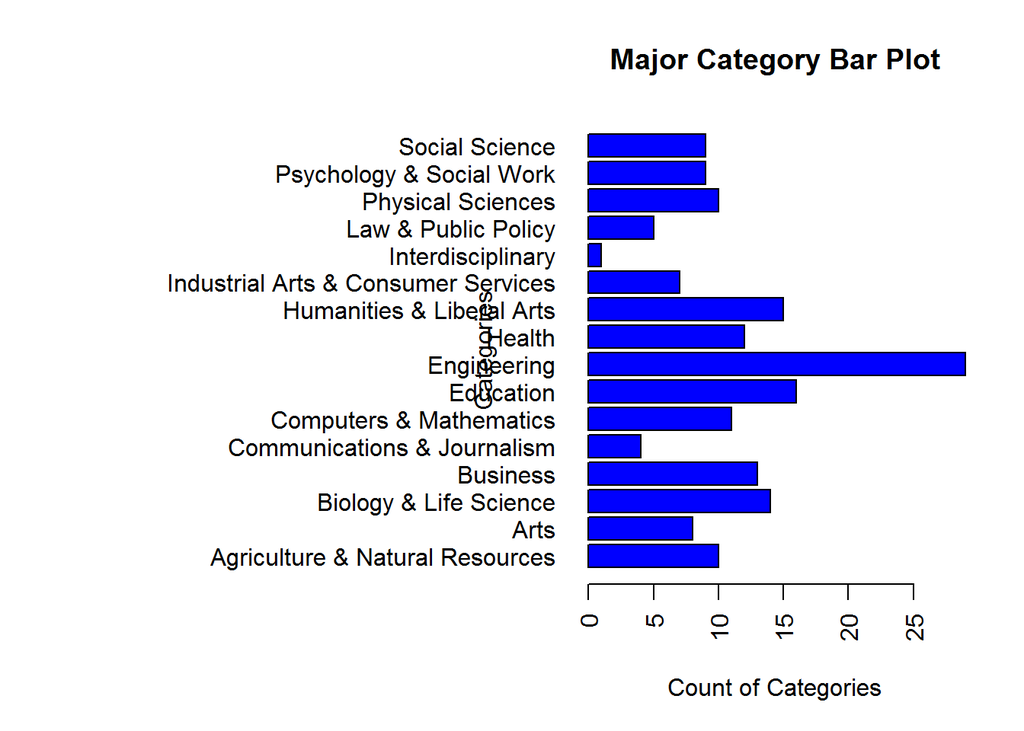

```r
par(las=2)
par(mar=c(5,20,4,2))
barplot(major_count$major_category,
        main="Major Category Bar Plot",
     xlab="Count of Categories",
     ylab="Categories",
     horiz = TRUE,
     col ="blue")
```

```r
write.csv(df, "538college.csv", row.names=FALSE)
```

## Git location: https://github.com/jjschueder/SMU_MSDS_homework.git